# Tarea 1: Exploración y Visualización de Datos

Felipe Bravo, Hernán Sarmiento, Aymé Arango, Alison Fernandez, Cinthia Mabel Sanchez, Juan Pablo Silva

Septiembre 2020

# 1 Declaración de compromiso ético

Nosotros Cristóbal Jaramillo y Vicente Ardiles, declaramos que realizamos de manera grupal los pasos de la presente actividad. También declaramos no incurrir en copia, ni compartir nuestras respuestas con otras personas ni con otros grupos. Por lo que, ratificamos que las respuestas son de nuestra propia confección y reflejan nuestro propio conocimiento.

# 2 Instrucciones

1. Trabajen en equipos de dos o tres personas. Salvo excepciones, no se corregirá entregas con menos de dos integrantes.
2. Modifique este archivo `.Rmd` agregando sus respuestas donde corresponda.
3. Para cada pregunta, cuando corresponda, **incluya el código fuente que utilizó para llegar a su respuesta**.
4. El formato de entrega para esta actividad es un archivo html. **Genere un archivo HTML usando RStudio** y súbalo a U-Cursos. Basta con que uno de los integrantes haga la entrega. Si ambos hacen una entrega en U-Cursos, se revisará cualquiera de éstas.

# 3 Tarea

La primera parte de esta actividad son preguntas teóricas que avanzaron en las clases del curso de Minería de datos.

## 3.1 Teoría

*1. ¿Cuál es el objetivo de Minería de datos y qué la diferencia de Machine Learning? De un ejemplo.*

**Respuesta:**

El objetivo de la minería de datos es generar conocimiento o patrones desconocidos a partir de grandes volúmenes de datos. A partir de estos datos se extrae información y se transforma en una estructura comprensible de la cual se extraigan conocimientos. Por otro lado el machine learning crea sistemas que puedan aprender automáticamente, generan predicciones.

Un asistente de texto automatico en una pagina web:

Machine Learning: A partir de los mensajes que le llegan del usuario, el programa predice que debe responder y de que forma.

Minería: A partir de muchas muestras de datos (conversaciones del este programa) podemos ver si esta funcionando correctamente o no y a que factores se debe.

*2. Describa y compare los siguientes métodos usados en Minería de datos: clasificación vs. clustering.*

**Respuesta:**

Clasificación:

Tiene un set de entrenamiento de atributos enfocados en clases. Se modelan en atributo clase. Se enfoca principalmente en clasificar datos nuevos asignándoles la clase más correcta, es decir, se tiene un set de datos que poseen atributos y se agrupan por clases (tienen atributos similares), luego llegan nuevos datos a los que se les debe asignar una clase de estas que se encuentran en el dataset.

Clustering:

Se tiene datos con un set de atributos y cierta semejanza entre si, su objetivo es encontrar conjuntos similares entre sí y también conjuntos que no tengan muchas similitudes.

En clasificación llegan datos sin una clase y se le asigna dependiendo sus atributos, mientras que clustering busca buscar semejanzas o diferencias entre grupos de datos.

*3. ¿Qué desafios existen en Minería de datos?*

**Respuesta:**

Dentro de los desafios actuales que podemos encontrar hoy en dia en Mineria de Datos se encuentran:

- Escalabilidad: Nuestro modelo sobre los datos funcione tanto a baja escala como a alta.
- Dimensionalidad: Podemos generar un modelo que tengas muchas caracterisiticas pero generar metodos eficiente sobre todas esas caracteristicas y que encuentre patrones reales puede llegar a ser muy costoso. Por otro lado puede que nuestro modelo tenga muy pocas dimensiones y no nos permite predecir o describir correctamente los datos.
- Datos complejos y heterogeneos: Datos sin una estructura definida (no estructurada) o datos que sean muy distintos entre si y que no permiten encontrar un patron o caracterisistica que nos permita describir los datos correctamente.
- Calidad de los datos: Los datos pueden que no esten de la forma que uno quisiera, puede que falten datos, no esten estructurados de la forma correcta, que exista desbalances en los datos generando analisis incorerectos, etc.
- Distribucion de los datos y propiedad
- Privacidad
- Streaming: Muchos de los datos que se encuentran en la red son flujos de datos, lo que signfica que son grandes volumenes de datos probablemente no estructurados y como consecuencia su costo de adquision sea muy alto.

*4. Respecto a los tipos de atributo, ¿cuál es la diferencia entre razón e intervalo?*

**Respuesta:**

En razón tenemos un “cero”, en decir, existe un valor minimo (o valor absoluto minimo) de toda la escala, en cambio en los intervalos no tenemos un rango especificado, podemos tener valores tanto negativos como positivos. Por otro lado los datos de tipo razon tienen la operacion de producto y division, operacion que los intervalos no tienen.

*5. ¿Qué factores que ocasionan errores en el análisis de datos deben ser considerados para la limpieza de un set de datos?*

**Respuesta:**

Los factores que ocasionan errores son los siguientes:

- Ruido y outliers
- Valores faltantes
- Datos duplicados

*6. ¿Qué es el análisis exploratorio de datos o EDA?*

**Respuesta:**

Es un conjunto de tecnicas para comprender de manera rapida la naturaleza de una coleccion de datos o dataset, basada principalmente en dos criterios: Las estadisticas de resumen y la visualizacion de datos.

*7. Describa las medidas de tendencia central: media y mediana. Exponga la diferencia entre ambas.*

**Respuesta:**

Media:

Es el promedio de todos los elementos, en otras palabras es la suma de todos los elementos divido en el total.

Mediana:

Teniendo todos los elementos de alguna observacion ordenados de menor a mayor la mediana representa la posicion central que separa la mitad inferior y superior de dichas observaciones, es decir, es el valor que esta justo en medio de todas esas observaciones.

Una de las principales diferencias es que la media es muy sensible a los outliers, en cambio la mediana mucho mas robusta al ruido.

*8. ¿Qué es una matriz de correlación y para qué sirve?*

**Respuesta:**

Es una matriz que contiene en sus celdas el coeficiente de correlacion para cada par de variables numericas con un valor entre -1 y 1. Nos sirve para saber como se comportan las variables entre ellas, por ejemplo, si dos variables tienen un valor cercano a 1 significa que si una crece la otra tambien lo hara, en caso contrario si es cercano a -1 tenemos una relacion inversa. Si la correlacion es cercana a 0 tenenos independencia entre ambas variables.

*9. Explique cómo se construye un Boxplot y exponga cómo se identifican los valores atípicos u outliers en este tipo de gráfico.*

**Respuesta:**

Los Bloxplot se construyen a partir de los percentiles. Se hace un rectangulo con el pirmer y tercer cuartil dividiendo dicho cuadrdado por la mitad usando la mediana. La altura de este rectangulo es la resta estre los cuantiles anteriores $Q_3 - Q_1$ (RIC) que se utiliza para proyectar una recta por ambos extremos de largo: $Q_1 - 1.5 \cdot RIC$ (recta inferior) y $Q_3 + 1.5 \cdot RIC$ (recta superior), si un valor es mas extremo que el largo de alguno de los brazos se consideran atípicos u outliers.

## 3.2 Práctica

En esta parte de la actividad se trabajará con los datos del Proceso Constituyente 2016-2017 publicados en el Portal de Datos Abiertos del Gobierno de Chile, para mayor información pueden ingresar al siguiente link: https://datos.gob.cl/dataset/proceso-constituyente-abierto-a-la-ciudadania. Los datos corresponden a las actas de los Encuentros Locales Autoconvocados (ELAs), en cada cual, un grupo de personas se reune a discutir distintos conceptos como por ejemplo: salud, educación, seguridad, etc.

Los datos con los que trabajarán consisten en la cantidad de veces que cada concepto constitucional fue mencionado por cada localidad de Chile.

Para cargar los datos, use:

```r
data_tf <- read.csv("http://dcc.uchile.cl/~hsarmien/mineria/datasets/actas.txt", header = T)
```

**Por cada pregunta adjunte el código R que utilizó para llegar a la respuesta. Respuestas sin código no recibirán puntaje**

### 3.2.1 Exploración básica

1. ¿Cuáles son las dimensiones del dataset (filas, columnas)? Adjunte código o indique cómo determinó la cantidad de datos total.

```r
nrow(data_tf)
```

```
## [1] 328
```

```r
ncol(data_tf)
```

```
## [1] 113
```

```r
#Filas = 328
#Columnas = 113
```

2. ¿Qué describe cada línea del dataset? (ejemplifique tomando la fila 85)

```r
data_tf[85,]
```

```
##                   localidad a_huelga a_la_educacion a_la_honra._al_honor
## 85 Coquimbo/Elqui/Andacollo        0              1                    0
##    a_la_identidad_cultural a_la_informacion a_la_integracion_de_discapacidad
## 85                       0                0                                0
##    a_la_integridad_fisica_y_psiquica a_la_nacionalidad a_la_participacion
## 85                                 1                 1                  0
##    a_la_salud a_la_seguridad.vida_sin_violencia a_la_seguridad_social a_la_vida
## 85          2                                 0                     0         0
##    a_la_vivienda_digna a_sindicalizarse_y_a_la_negociacion_colectiva
## 85                   1                                             0
##    a_sufragio.votar acceso_a_informacion_publica acceso_a_la_cultura
## 85                2                            0                   0
##    al_salario_equitativo al_trabajo amistad_civica autonomia.libertad
## 85                     0          1              2                  0
##    bien_comun.comunidad cambio_o_reforma_constitucional ciudadania
## 85                    0                               0          0
##    congreso_o_parlamento_.estructura_y_funciones.
## 85                                              2
##    contraloria_general.tribunales_de_cuentas cumplimiento_de_las_leyes_y_normas
## 85                                         1                                  2
##    cumplimiento_de_obligaciones_fiscales
## 85                                     0
##    cumplimiento_de_tratados_y_obligaciones_internacionales
## 85                                                       2
##    de_los_pueblos_indigenas de_peticion_ante_las_autoridades de_propiedad
## 85                        1                                0            0
##    de_proteccion_y_conservacion_de_patrimonio_historico_y_cultural
## 85                                                               3
##    de_satisfacer_cargas_publicas
## 85                             1
##    deberes_de_proteccion_de_conservacion_de_la_naturaleza
## 85                                                      3
##    defensor_del_pueblo.ciudadano democracia derecho_de_asociacion
## 85                             0          1                     0
##    derechos_del_nino._nina_y_adolescente desarrollo descentralizacion dignidad
## 85                                     0          0                 1        2
##    diversidad division_territorial
## 85          0                    0
##    ejercicio_legitimo_y_no_abusivo_de_los_derechos emprendimiento_libre
## 85                                               1                    0
```

[output cut: 33 more lines]

```
## 85                      0        0                                   0
##    proteccion._promocion_y_respeto_de_los_derechos_humanos_y_fundamentales
## 85                                                                       2
##    republica respeto respeto.conservacion_de_la_naturaleza_o_medio_ambiente
## 85         0       2                                                      3
##    respeto_a_la_naturaleza.medio_ambiente respeto_de_derechos_de_otros
## 85                                      2                            3
##    respeto_por_la_constitucion responsabilidad reunion_pacifica
## 85                           4               0                0
##    regimen_de_gobierno_presidencial.semi.presidencial.parlamentario seguridad
## 85                                                                1         1
##    ser_elegido_en_cargos_publicos servicio_a_la_comunidad soberania solidaridad
## 85                              1                       1         0           0
##    subsidiaridad tolerancia transparencia_y_publicidad unidad
## 85             0          0                          0      0
```

```r
# Cada fila del dataset representa la participación de localidades en distintos conceptos. La primera columna
# de la fila se presenta el nombre del lugar donde se tomaron los datos y las demas columnas son numeros enteros que
# entregan el grado de participación de esa localidad en distintos puntos (huelga, educación, etc).

# Por ejemplo para el caso de la fila 85, su localidad es Coquimbo/Elqui/Andacollo, donde hubo 0 mención a huelga, 1 mención de eduación, etc
```

3. ¿Existen localidades repetidas en el dataset? Adjunte el código o indique cómo llegó a esa conclusión.

```r
library(dplyr)
data <- data_tf %>%
  group_by(localidad)

nrow(data_tf)
```

```
## [1] 328
```

```r
nrow(data)
```

```
## [1] 328
```

```r
#Al crear un dataframe agrupando las localidades y calculando sus filas, se aprecia que son la misma cantidad
#Que el dataframe sin agrupar, por lo que no existen localidades repetidas
```

4. Liste los nombres de las columnas del dataset `data_tf`. Adjunte código en R y *recuerde* usar `head` si el resultado es muy largo.

```r
head(names(data_tf))
```

```
## [1] "localidad"               "a_huelga"
## [3] "a_la_educacion"          "a_la_honra._al_honor"
## [5] "a_la_identidad_cultural" "a_la_informacion"
```

### 3.2.2 Análisis

1. Liste todas las localidades donde *no* se discutió el concepto `a_la_salud`.

```r
data_tf[data_tf$a_la_salud==0, "localidad"]
```

```
##  [1] "Aisen del General Carlos Ibanez del Campo/Capitan Prat/O'higgins"
##  [2] "Antofagasta/El Loa/San Pedro de Atacama"
##  [3] "Arica y Parinacota/Arica/Camarones"
##  [4] "Biobio/Bio Bio/Alto Biobio"
##  [5] "Biobio/Bio Bio/Laja"
##  [6] "Biobio/Bio Bio/Negrete"
##  [7] "Biobio/Concepcion/Santa Juana"
##  [8] "Biobio/Nuble/San Fabian"
##  [9] "La Araucania/Malleco/Ercilla"
## [10] "Los Lagos/Osorno/Puerto Octay"
## [11] "Los Rios/Ranco/Futrono"
## [12] "Los Rios/Valdivia/Corral"
## [13] "Magallanes y de la Antartica Chilena/Tierra del Fuego/Timaukel"
## [14] "Maule/Talca/Empedrado"
## [15] "Tarapaca/El Tamarugal/Camina"
## [16] "Valparaiso/Quillota/Hijuelas"
## [17] "Valparaiso/Valparaiso/Juan Fernandez"
```

2. Liste las 10 localidades que más mencionaron el concepto `justicia`.

```r
d <- data_tf[order(data_tf$justicia, decreasing = TRUE), "localidad"]
d[0:10]
```

```
##  [1] "Metropolitana de Santiago/Santiago/Santiago"
##  [2] "Metropolitana de Santiago/Santiago/Providencia"
##  [3] "Metropolitana de Santiago/Santiago/Nunoa"
##  [4] "Metropolitana de Santiago/Santiago/Las Condes"
##  [5] "Metropolitana de Santiago/Cordillera/Puente Alto"
##  [6] "Valparaiso/Valparaiso/Valparaiso"
##  [7] "Metropolitana de Santiago/Santiago/La Florida"
##  [8] "Valparaiso/Valparaiso/Vina del Mar"
##  [9] "Antofagasta/Antofagasta/Antofagasta"
## [10] "Tarapaca/Iquique/Iquique"
```

3. Liste los 10 conceptos menos mencionados a lo largo de todo el proceso.

```r
d <- colSums(data_tf[,-1])
cantidad <- d[order(d, decreasing = FALSE)]
d <- data.frame(cantidad)
nombres <- names(cantidad)
nombres[0:10]
```

```
##  [1] "igualdad_ante_las_cargas_publicas" "libertad_ambulatoria"
##  [3] "a_la_honra._al_honor"              "reunion_pacifica"
##  [5] "de_peticion_ante_las_autoridades"  "patriotismo"
##  [7] "igualdad_ante_los_tributos"        "unidad"
##  [9] "a_la_nacionalidad"                 "ser_elegido_en_cargos_publicos"
```

4. Liste las 10 localidades que más participaron en el proceso. Describa cómo definió su medida de participación.

```r
d <- rowSums(data_tf[,-1])
d <- data.frame(localidad=data_tf[,"localidad"], cantidad=d)
d <- d[order(d$cantidad, decreasing = TRUE), "localidad"]
d[0:10]
```

```
##  [1] "Metropolitana de Santiago/Santiago/Santiago"
##  [2] "Metropolitana de Santiago/Santiago/Providencia"
##  [3] "Metropolitana de Santiago/Santiago/Nunoa"
##  [4] "Metropolitana de Santiago/Santiago/Las Condes"
##  [5] "Valparaiso/Valparaiso/Valparaiso"
##  [6] "Metropolitana de Santiago/Cordillera/Puente Alto"
##  [7] "Metropolitana de Santiago/Santiago/La Florida"
##  [8] "Metropolitana de Santiago/Santiago/La Reina"
##  [9] "Valparaiso/Valparaiso/Vina del Mar"
## [10] "La Araucania/Cautin/Temuco"
```

La medida de participación se realizo con la suma total de las menciones, es decir quien poseia más menciones, tenia una mayot participacion en el proceso.

5. Ejecute el siguiente código que permitirá agregar una nueva columna a nuestro dataframe que solo tendrá el nombre de la región.

```r
regiones <- strsplit(as.character(data_tf[,1]), '/')
data_tf$region <- sapply(regiones, "[[", 1)
data_tf <- data_tf %>% select(localidad, region, everything())
```

Luego, genere un gráfico de barras (ggplot) que muestre los 10 conceptos más mencionados en cada una de las regiones mencionadas (adjunte gráficos y código):

- `Atacama`
- `Coquimbo`
- `Metropolitana de Santiago`

Cabe resaltar, que se esperan tres gráficos de barras para las tres diferentes regiones:

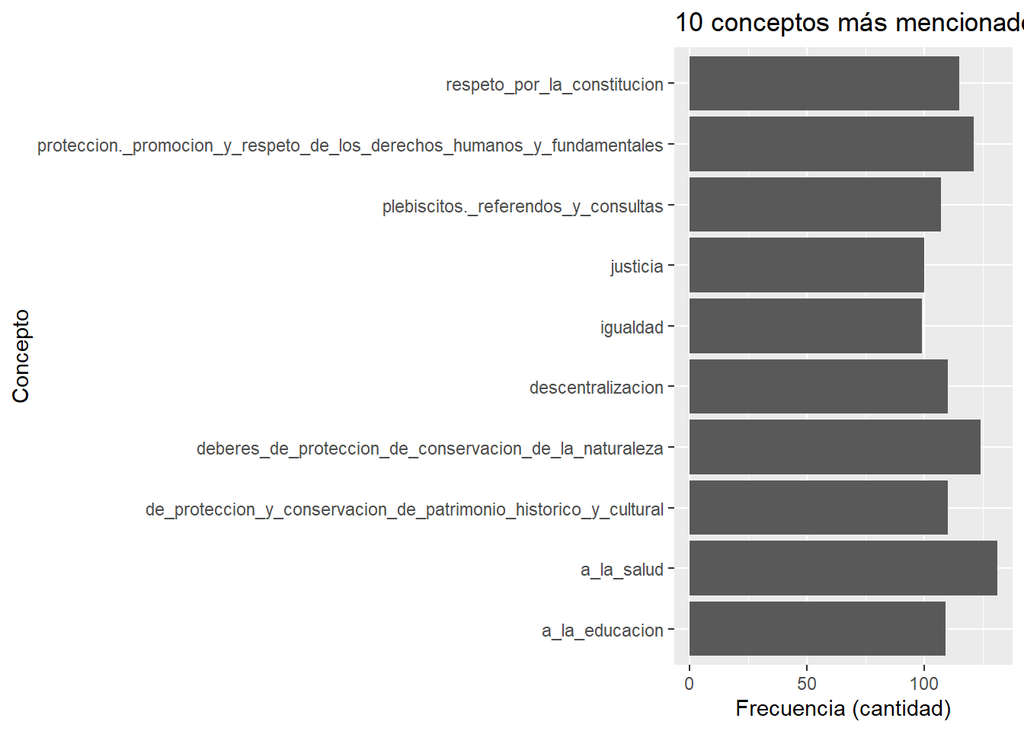

```r
# 10 conceptos más mencionados en Atacama
atacama_df <- data_tf[data_tf$region == "Atacama",]
nombres <- names(atacama_df[,-2:-1])
new_data <- data.frame(concepto = nombres, total = colSums(atacama_df[,-2:-1]))
new_data <- new_data[order(new_data$total, decreasing = TRUE),]
new_data <- new_data[0:10,]

library(ggplot2)  # cargamos la librería

ggplot(new_data) +   # asociamos un data frame a ggplot
  geom_bar(aes(x = concepto, y = total), stat="identity") +
  coord_flip() +
  ggtitle("10 conceptos más mencionados en Atacama") +
  xlab("Concepto") + ylab("Frecuencia (cantidad)")
```

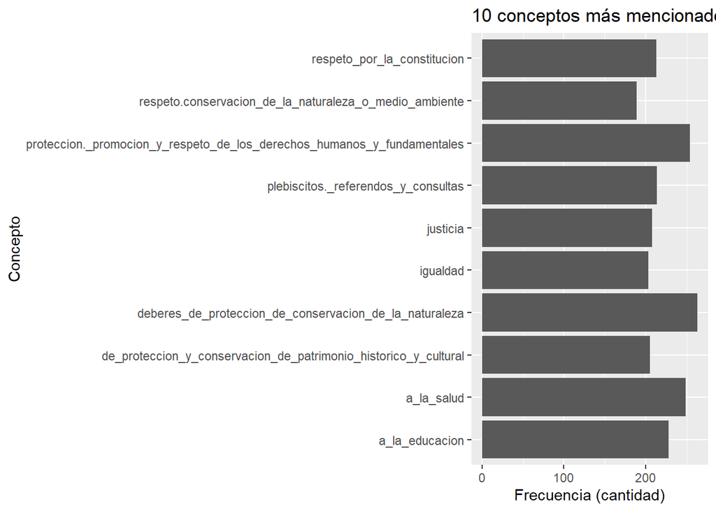

```r
# 10 conceptos más mencionados en Coquimbo
coquimbo_df <- data_tf[data_tf$region == "Coquimbo",]
nombres <- names(coquimbo_df[,-2:-1])
new_data <- data.frame(concepto = nombres, total = colSums(coquimbo_df[,-2:-1]))
new_data <- new_data[order(new_data$total, decreasing = TRUE),]
new_data <- new_data[0:10,]

library(ggplot2)  # cargamos la librería

ggplot(new_data) +   # asociamos un data frame a ggplot
  geom_bar(aes(x = concepto, y = total), stat="identity") +
  coord_flip() +
  ggtitle("10 conceptos más mencionados en Coquimbo") +
  xlab("Concepto") + ylab("Frecuencia (cantidad)")
```

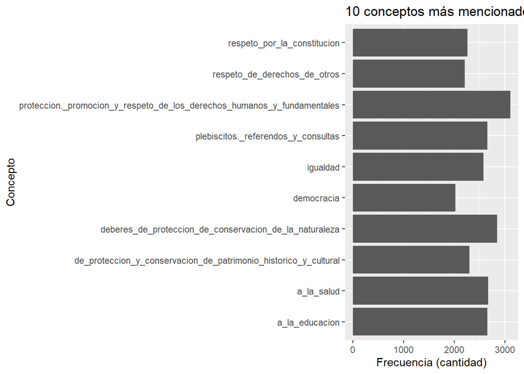

```r
# 10 conceptos más mencionados en Metropolitana de Santiago
santiago_df <- data_tf[data_tf$region == "Metropolitana de Santiago",]
nombres <- names(santiago_df[,-2:-1])
new_data <- data.frame(concepto = nombres, total = colSums(santiago_df[,-2:-1]))
new_data <- new_data[order(new_data$total, decreasing = TRUE),]
new_data <- new_data[0:10,]

library(ggplot2)  # cargamos la librería

ggplot(new_data) +   # asociamos un data frame a ggplot
  geom_bar(aes(x = concepto, y = total), stat="identity") +
  coord_flip() +
  ggtitle("10 conceptos más mencionados en Santiago") +
  xlab("Concepto") + ylab("Frecuencia (cantidad)")
```

6. De la pregunta anterior, ¿considera que es razonable usar el conteo de frecuencias para determinar las regiones que tuvieron mayor participación en el proceso? ¿Por qué? Sugiera y solamente comente una forma distinta de hacerlo.

**respuesta** En la pregunta anterior se calculaban las frecuencias de las 10 conceptos mas mencionados, lo que nos hace perder mucha información sobre los otros conceptos, esto genera que no sea una buena forma de determinar la partición de las comunas en el proceso pues puede pasar que en una comuna de poca participación, sus números se enfoquen en 10 conceptos y nada más, lo que nos daría malas conclusiones. La mejor forma seria sumar todas las frecuencias de los conceptos y de esta manera ordenarlos y ver las regiones mas participativas.

## 3.3 Ejercicios

### 3.3.1 Accidentes de tránsito

Para esta sección utilizaremos un dataset real de número de accidentes de tránsito por localidad, el cual puede ser encontrado en el siguiente link: http://datos.gob.cl/dataset/9348. Para cargar el dataset ejecute el siguiente código:

```r
tipos <- read.table("https://users.dcc.uchile.cl/~hsarmien/mineria/datasets/accidentes_2010_2011.txt")
head(tipos)
```

```
##    Muestra                   Descripcion Anio TipoAccidente Cantidad
## 1 Nacional                      Nacional 2010     Atropello     8247
## 2 Nacional                      Nacional 2011     Atropello     8339
## 3 Regional XV RegiÃ³n Arica y Parinacota 2010     Atropello      115
## 4 Regional XV RegiÃ³n Arica y Parinacota 2011     Atropello      159
## 5  Comunal                         ARICA 2010     Atropello      115
## 6  Comunal                         ARICA 2011     Atropello      158
```

Explore el set de datos para responder las siguientes preguntas:

1. Filtre los datos para incluir sólo los accidentes ocurridos el año 2011 a nivel regional. Genere un boxplot donde se indique la cantidad de accidentes categorizado por tipo de accidente.

Este tipo de gráfico nos ayudará a entender como se distribuye los datos por cada tipo de accidentes. Es decir, podremos apreciar que tan dispersos o similares son los datos en todo el dataset. También, puede ser útil para observar valores atípicos u outliers en los datos.

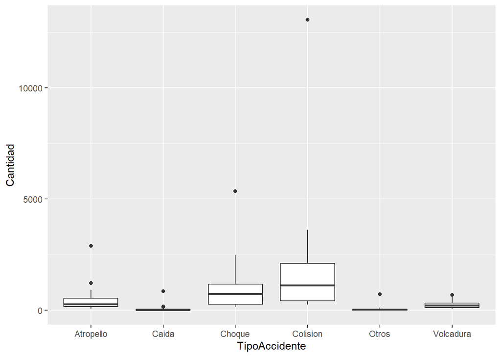

```r
df <- tipos[tipos$Muestra == "Regional" & tipos$Anio == "2011",]
ggplot(df, aes(x = TipoAccidente, y = Cantidad)) +
  geom_boxplot()
```

2. ¿Qué aprecia con el gráfico anterior? ¿Qué otra forma de explorar los datos podría agregar? ¿Qué información adicional aporta? Adjunte una breve explicación.

**Respuesta:**

En el grafico se puede apreciar que la mayor cantidad de accidentes son por colisión (pues su mediana es mayor) y luego choque, caída y otros posen muy pocas cantidades de accidentes. También es interesante fijarse en que colisión tiene un dato atípico muy alto, que por como esta hecha la tabla, podríamos concluir que corresponde a la región Metropolitana. Por lo general todos los tipos de accidentes tienen valores atípicos, que se puede decir que son de la Región Metropolitana. Otra forma de explorar los datos podría ser con un grafico de barras por años, esto aportaría la información de variación de los accidentes por año (ver si han aumentado, disminuido y de que tipo)

### 3.3.2 Diamantes

Considere el set de datos diamonds del paquete ggplot2 de R, que contiene los precios en dolares, junto con otros atributos importantes: quilates, corte, color y claridad. También hay medidas físicas como ser: x (largo), y (ancho), z (profundidad), depth (porcentaje total de profundidad) y table (ancho desde el tope del diamante al punto relativo más ancho del diamante):

```r
library(ggplot2)
data("diamonds")
head(diamonds)
```

```
## # A tibble: 6 x 10
##   carat cut       color clarity depth table price     x     y     z
##   <dbl> <ord>     <ord> <ord>   <dbl> <dbl> <int> <dbl> <dbl> <dbl>
## 1 0.23  Ideal     E     SI2      61.5    55   326  3.95  3.98  2.43
## 2 0.21  Premium   E     SI1      59.8    61   326  3.89  3.84  2.31
## 3 0.23  Good      E     VS1      56.9    65   327  4.05  4.07  2.31
## 4 0.290 Premium   I     VS2      62.4    58   334  4.2   4.23  2.63
## 5 0.31  Good      J     SI2      63.3    58   335  4.34  4.35  2.75
## 6 0.24  Very Good J     VVS2     62.8    57   336  3.94  3.96  2.48
```

Realice una exploración por el set de datos para responder las siguientes preguntas:

1. Teniendo en cuenta las medidas físicas, ¿considera que existen valores inexistentes o inconsistentes? Describa como manejaría esta situación. Adjunte el código necesario.

```r
# RESPUESTA
# resumen para ver diferencias entre pmedia y mediana, observandose que no existen diferencias muy grandes.
summary(diamonds)
```

```
##      carat               cut        color        clarity          depth
##  Min.   :0.2000   Fair     : 1610   D: 6775   SI1    :13065   Min.   :43.00
##  1st Qu.:0.4000   Good     : 4906   E: 9797   VS2    :12258   1st Qu.:61.00
##  Median :0.7000   Very Good:12082   F: 9542   SI2    : 9194   Median :61.80
##  Mean   :0.7979   Premium  :13791   G:11292   VS1    : 8171   Mean   :61.75
##  3rd Qu.:1.0400   Ideal    :21551   H: 8304   VVS2   : 5066   3rd Qu.:62.50
##  Max.   :5.0100                     I: 5422   VVS1   : 3655   Max.   :79.00
##                                     J: 2808   (Other): 2531
##      table           price             x                y
##  Min.   :43.00   Min.   :  326   Min.   : 0.000   Min.   : 0.000
##  1st Qu.:56.00   1st Qu.:  950   1st Qu.: 4.710   1st Qu.: 4.720
##  Median :57.00   Median : 2401   Median : 5.700   Median : 5.710
##  Mean   :57.46   Mean   : 3933   Mean   : 5.731   Mean   : 5.735
##  3rd Qu.:59.00   3rd Qu.: 5324   3rd Qu.: 6.540   3rd Qu.: 6.540
##  Max.   :95.00   Max.   :18823   Max.   :10.740   Max.   :58.900
##
##        z
##  Min.   : 0.000
##  1st Qu.: 2.910
##  Median : 3.530
##  Mean   : 3.539
##  3rd Qu.: 4.040
##  Max.   :31.800
##
```

```r
# Por otra parte se puede notar que en en los atributos (x,y,z) existe un valor minimo igual a 0, lo cual es imposible al tratarse de las dimensiones de un objeto.
```

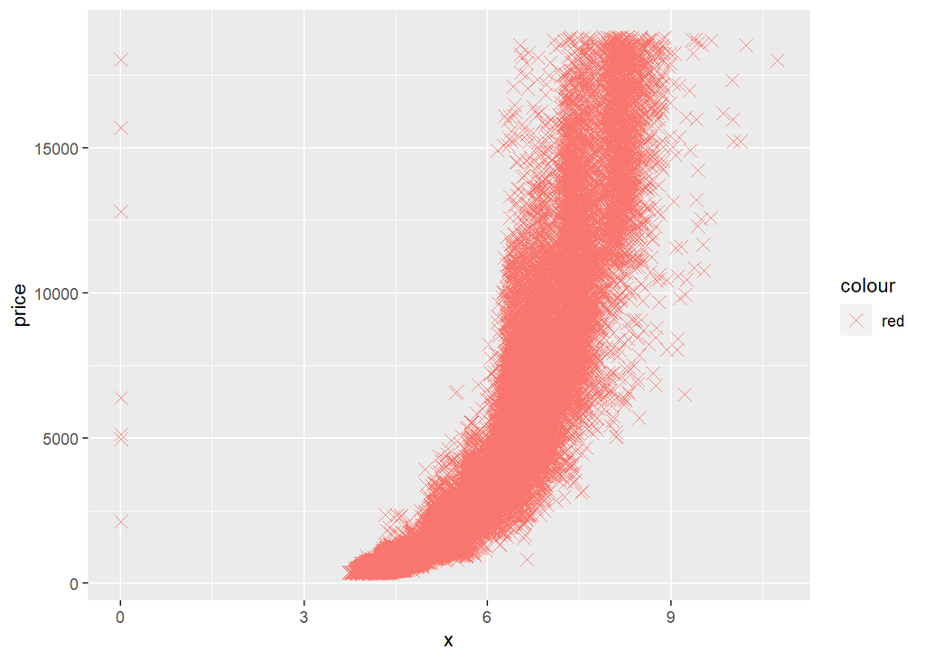

```r
# Hacemos un grafico de dispersion con uno de estos atributos y el precio para ver que esta pasando
ggplot(diamonds, aes(x=x, y=price, color="red")) +
  geom_point(size=3,shape=4)
```

```r
# notamos que si existen valores incosistentes, probablemente mal ingresados, debido a que tenemos diamantes sin medidas pero que tienen un precio definido.
sum(diamonds$x == 0) # 8
```

```
## [1] 8
```

```r
sum(diamonds$y == 0) # 7
```

```
## [1] 7
```

```r
sum(diamonds$z == 0) # 20
```

```
## [1] 20
```

```r
# Al tratarse de que la cantidad de datos inconsistentes es muy baja (menos de 20) en comparacion a la cantidad de datos consistentes (+50.000) una forma de manejar esto seria eliminarlos del analisis. Otra posible forma seria hacer una aproximacion de sus dimensiones en base al precio suponiendo que se haya ingresado correctamente.
```

```r
# Analisis de valores faltantes
sapply(diamonds, function(x) sum(is.na(x))) # se observa que no existen valores faltantes
```

```
##   carat     cut   color clarity   depth   table   price       x       y       z
##       0       0       0       0       0       0       0       0       0       0
```

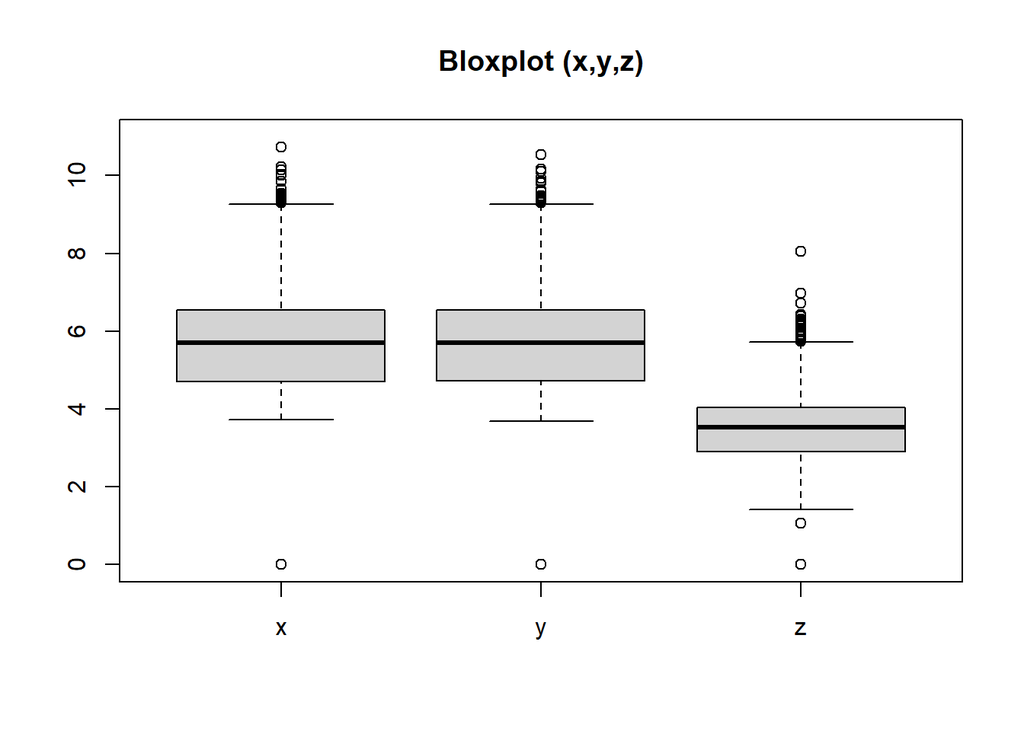

```r
# 1
# Al hacer un bloxplot de los atributos fisicos se observa una cantidad considerable de outliers
boxplot(x = diamonds[c("x","y","z")], ylim=c(0,11), main = "Bloxplot (x,y,z)")
```

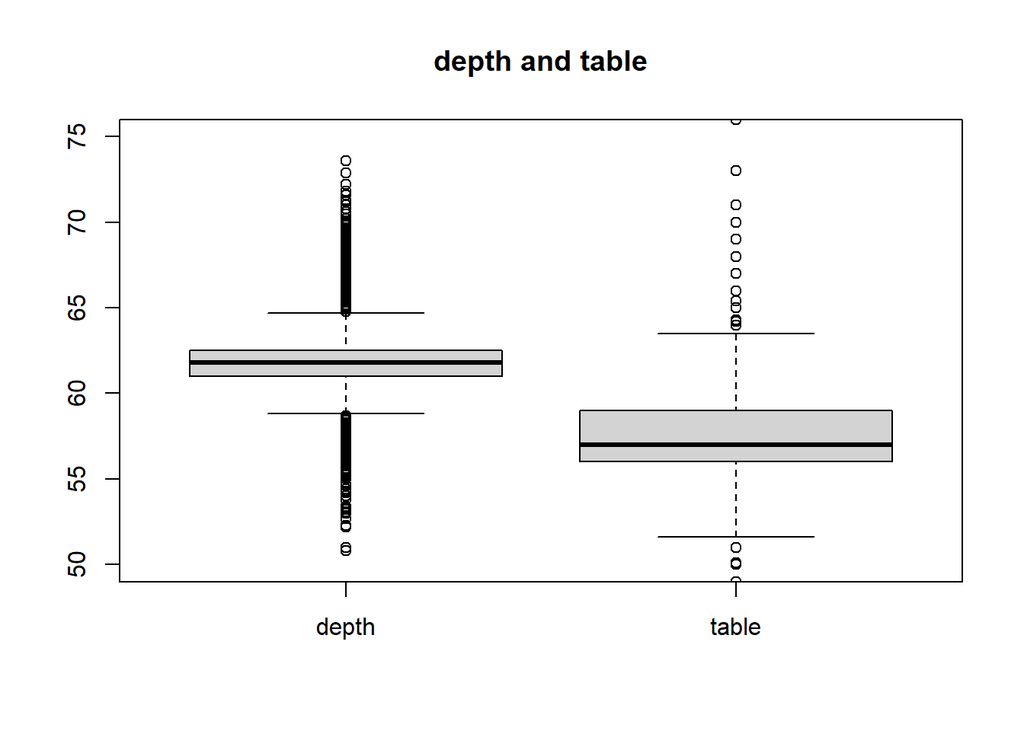

```r
# 1
# En particular en el atributo depth es bastante mayor esta cantidad de outliers y con cierta simentria en torno al boxplot.
boxplot(x = diamonds[c("depth", "table")],ylim=c(50,75), main = "depth and table")
```

```r
# Estos casos de outliers que son una cantidad mas considerable se podrian manjear a futuro como una clase especial de diamantes que haga que se diferencien del resto.
```

2. Considerando la relación entre dos atributos, ¿qué atributos están más correlacionadas con el precio (price) y qué significa esto? ¿cuál es la correlación más alta para table? Adjunte el código necesario para la respuesta.

```r
# RESPUESTA
# - precio: Numericamente al hacer una matriz de correlacion se tiene que las dimensiones del diamante (x,y,z) afectan directamente el valor del este (fuertemente correlacionados), esto quiere decir que si un diamante es mas largo, ancho o profundo su precio sera mayor, lo cual es razonable al tratarse de un diamante mas grande.
# - table: En general se tienen correlaciones mas cercana a 0 que a 1/-1 pero la mas alta seria el atributo "x" que tiene una correlacion positiva debil, por otro lado, el atributo "depth" tiene una correlacion negativa con table un poco mas fuerte que "x".
cor(diamonds[,5:10])
```

```
##             depth      table      price           x           y          z
## depth  1.00000000 -0.2957785 -0.0106474 -0.02528925 -0.02934067 0.09492388
## table -0.29577852  1.0000000  0.1271339  0.19534428  0.18376015 0.15092869
## price -0.01064740  0.1271339  1.0000000  0.88443516  0.86542090 0.86124944
## x     -0.02528925  0.1953443  0.8844352  1.00000000  0.97470148 0.97077180
## y     -0.02934067  0.1837601  0.8654209  0.97470148  1.00000000 0.95200572
## z      0.09492388  0.1509287  0.8612494  0.97077180  0.95200572 1.00000000
```

3. Proponga otra forma para explorar los datos. ¿Qué información adicional aporta? Adjunte una breve explicación.

**Respuesta:**

Inspirado en la pregunta anterior, donde se busca correlacion en los atributos fisicos de un diamante y su precio, se puede explorar la distribucion del precio pero no en base a otro dato numerico si no en base a los datos categoricos, por ejemplo que tanto afecta el gusto de las personas en el color de un diamante y su precio o si la claridad o corte del diamante afectan la valorizacion que tenga este. Esta distribucion se puede visualizar en un boxplot donde cada caja representaria un color, corte o claridad.